# Praca domowa 2

Aleksander Brandt

## Dane

Dane wykorzystane w Pracy domowej 2 opisują wycenę nieruchmości. Każda obserwacja jest pewną nieruchmością, która posiada informacje takie jak powierzchnia, liczba pokoi, liczba łazienek i wiele więcj. Opis wszystkich kolumn w pliku `README.md`.

## Zadanie 1

Jak wygląda rozkład ceny nieruchomości w poszczególnych kodach pocztowych na przestrzeni lat? Rozważamy kody pocztowe, które mają więcej niż 280 posiadłości.

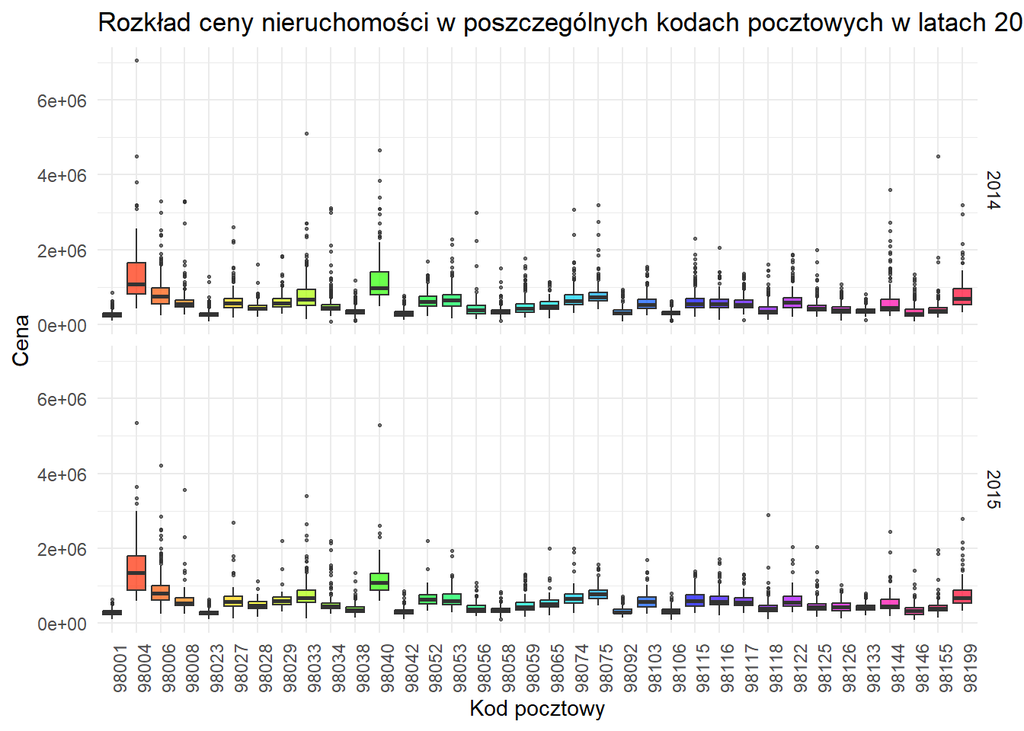

```r
df1 <- df %>%
  mutate(year = substr(date, 1, 4)) %>%
  group_by(zipcode) %>%
  filter(n() > 280) %>%
  ungroup()


ggplot(df1, aes(x = as.factor(zipcode), y = price, fill = as.factor(zipcode))) +
  geom_boxplot(outlier.size = 0.5, alpha = 0.7) +
  labs(title = "Rozkład ceny nieruchomości w poszczególnych kodach pocztowych w latach 2014 i 2015",
       x = "Kod pocztowy",
       y = "Cena",
       fill = "Kod pocztowy") +
  facet_grid(rows = vars(year)) +
  theme_minimal() +
  theme(legend.position = "none",
        axis.text.x = element_text(angle = 90, hjust = 1)) +
  scale_fill_manual(values = rainbow(length(unique(df1$zipcode))))
```

**Komentarz:**

wsrod mieszkan pod podanymi kodami pocztowymi znajduja sie takie, ktore znaczaco odbiegaja cenowo od wiekszosci mieszkan pod tym kodem pocztowym w 2014 te odchyly od cen wiekszosci mieszkan byly wyzsze, niz w 2015

## Zadanie 2

Czy jest różnica w rozkładzie ceny nierchomości od powierzchni mieszkalnej uwzględniając podział na nieruchomości z piwnicą i bez?

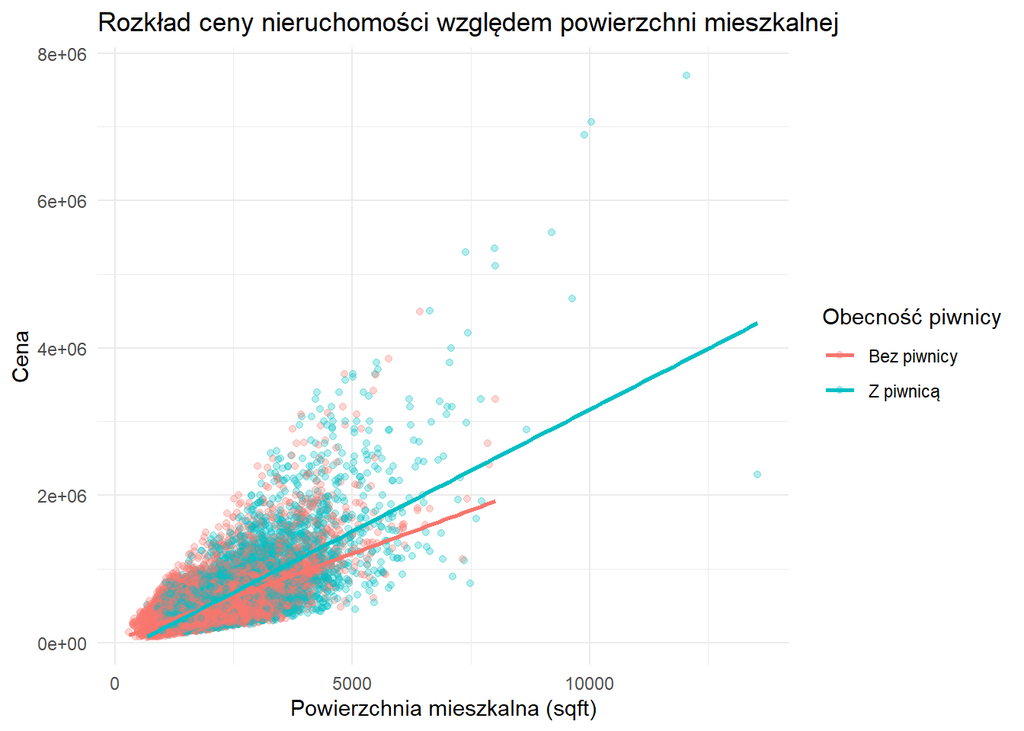

```r
df2 <- df %>%
  mutate(has_basement = ifelse(sqft_basement > 0, "Z piwnicą", "Bez piwnicy"))

ggplot(df2, aes(x = sqft_living, y = price, color = has_basement)) +
  geom_point(alpha = 0.3) +
  geom_smooth(method = "lm", se = FALSE) +
  labs(title = "Rozkład ceny nieruchomości względem powierzchni mieszkalnej",
       x = "Powierzchnia mieszkalna (sqft)",
       y = "Cena",
       color = "Obecność piwnicy") +
  theme_minimal()
```

**Komentarz:**

tak, jest, na korzysc tych z piwnica tendencja jest taka, że im większy metraz, tym wieksza roznica miedzy cena mieszkania z piwnica, a bez niej (oczywiscie na korzysc mieszkania z piwnica)

## Zadanie 3

Jaka jest zależność pomiędzy jakością wykończenia nieruchomości a liczbą pięter?

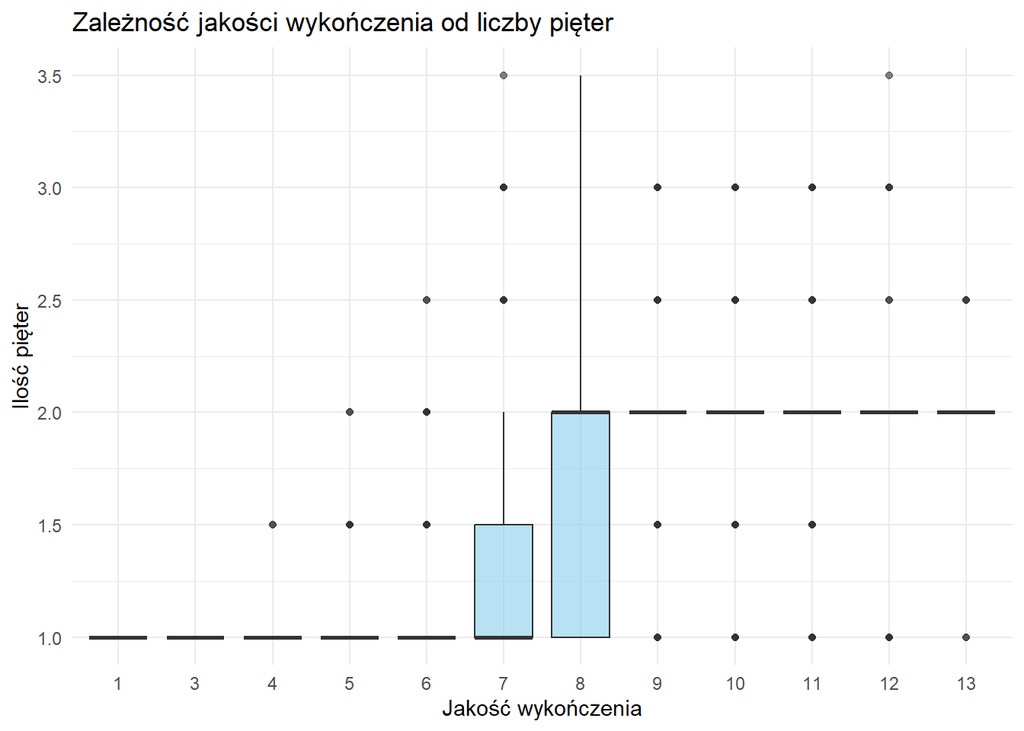

```r
df3 <- df %>%
  distinct(id, .keep_all = TRUE)

ggplot(df3, aes(x = factor(grade), y = floors)) +
  geom_boxplot(alpha = 0.6, fill = "skyblue") +
  labs(title = "Zależność jakości wykończenia od liczby pięter",
       x = "Jakość wykończenia",
       y = "Ilość pięter") +
  theme_minimal()
```

**Komentarz:**

## Zadanie 4

Jaka jest zależność między powierzchnią mieszkalną nieruchomości a powierzchnią gruntu w podziale na liczbę sypialni?

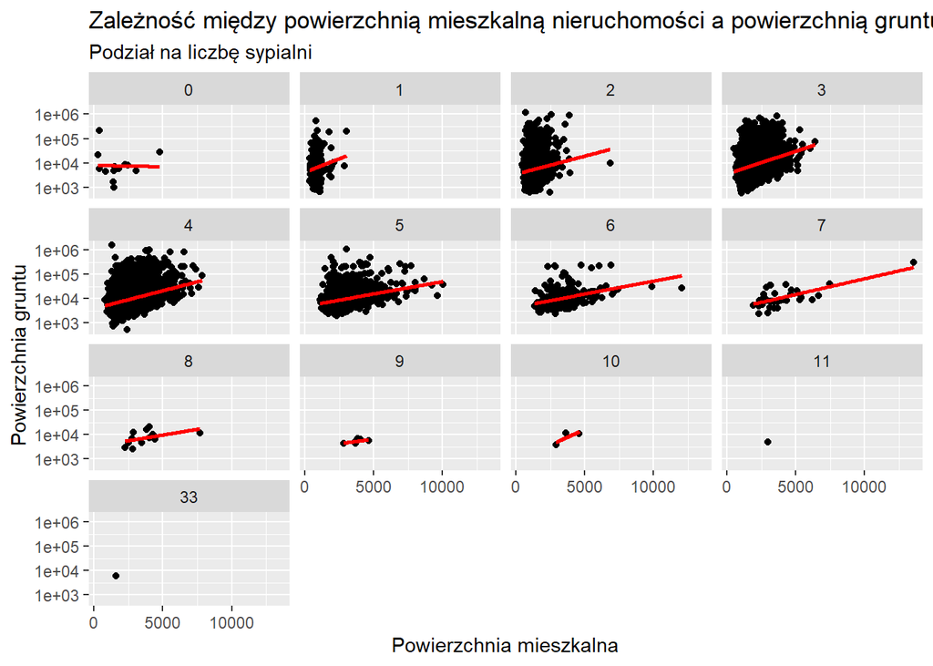

```r
df4 <- df %>%
  distinct(id, .keep_all = TRUE)

ggplot(df4, aes(y = sqft_lot, x = sqft_living)) +
  geom_point() +
  geom_smooth(method = "lm", color = "red", se = FALSE) +
  facet_wrap(~bedrooms) +
  labs(title = "Zależność między powierzchnią mieszkalną nieruchomości a powierzchnią gruntu",
       subtitle = "Podział na liczbę sypialni",
       x = "Powierzchnia mieszkalna",
       y = "Powierzchnia gruntu") +
  scale_y_log10()
```

**Komentarz:**

w geom_smooth chcialem dac parametre method = ‘loess’, ale niestety zbior danych jest za duzy i z tego tyulu dostawalem errory

nie ma specjalniej zaleznosci dla mieszkan bez sypialni, jest to przypadek szczegolny ogolna tendencja jest taka, ze im wieksza powierzchnia mieszkania, tym wieksza powierzchnia gruntu wyriznic mozna mieszkania o 1 sypialni, dla ktorych ta tendencja jest wyjatkowo wysoka oraz mieszkania o 5 sypialniach, gdzie to tendencja ta ma najwolniejszy wzrost, pomijajac mieszkania o ilosci sypialni wiekszej niz 7 - jest ich na tyle malo, ze nalezy je rozpatrywac jako osobne przypadki widac to chocby po tym, ze mieszkania o 9 sypialniach maja badany wzrost bardzo niski, podczas gdy dla mieszkan z 8 i 10 sypialniami jest wyzszy

## Zadanie 5

Rozważmy tylko nieruchomości, które miały remont. W której dekadzie było najwięcej przeprowadzonych remontów? Czy w poszczególnych dekadach jest porównywalny procent nieruchmości dla każdej wartości miary jakości i wykończenia nieruchomości?

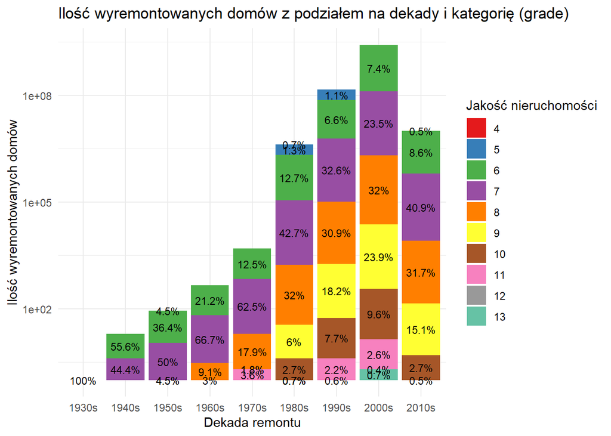

```r
df5 <- df %>%
  distinct(id, .keep_all = TRUE) %>%
  mutate(decade_r = case_when(
    yr_renovated >= 1930 & yr_renovated < 1940 ~ "1930s",
    yr_renovated >= 1940 & yr_renovated < 1950 ~ "1940s",
    yr_renovated >= 1950 & yr_renovated < 1960 ~ "1950s",
    yr_renovated >= 1960 & yr_renovated < 1970 ~ "1960s",
    yr_renovated >= 1970 & yr_renovated < 1980 ~ "1970s",
    yr_renovated >= 1980 & yr_renovated < 1990 ~ "1980s",
    yr_renovated >= 1990 & yr_renovated < 2000 ~ "1990s",
    yr_renovated >= 2000 & yr_renovated < 2010 ~ "2000s",
    yr_renovated >= 2010 & yr_renovated <= 2020 ~ "2010s",
    TRUE ~ "No Renovation"
  )) %>%
  group_by(decade_r, grade) %>%
  summarise(renovated_count = n()) %>%
  ungroup() %>%
  filter(decade_r != 'No Renovation') %>%
  mutate(grade = as.factor(grade)) %>%
  group_by(decade_r) %>%
  mutate(percentage = (renovated_count / sum(renovated_count)) * 100)


colors <- c("#E41A1C", "#377EB8", "#4DAF4A", "#984EA3", "#FF7F00", "#FFFF33", "#A65628", "#F781BF", "#999999", "#66C2A5")

ggplot(df5, aes(x = decade_r, y = renovated_count, fill = grade)) +
  geom_bar(stat = "identity", position = "stack") +
  labs(x = "Dekada remontu", y = "Ilość wyremontowanych domów",
       title = "Ilość wyremontowanych domów z podziałem na dekady i kategorię (grade)",
       fill = "Jakość nieruchomości") +
  theme_minimal() +
  scale_fill_manual(values = colors) +
  scale_y_log10() +
  geom_text(aes(label = paste0(round(percentage, 1), "%")),
            position = position_stack(vjust = 0.5), size = 3)
```

**Komentarz:**

najwiecej renowacji bylo w latach 2000, nie ma zadnego grade, ktory wykazalby sie powtarzalnoscia w tym, ile procent remontow w danej dekadzie stanowi

niepotrafilem tego zrobic czytelniej na 1 wykresie ;(

## Zadanie 6

Jak prezentuje się wartość minimalna, średnia i maksymalna ceny nieruchmości w podziele na rok budowy nieruchomości.

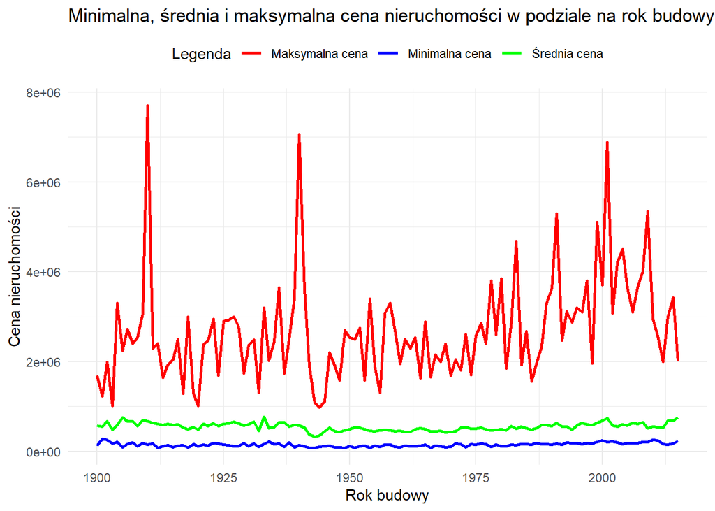

```r
df6 <- df %>%
  group_by(yr_built) %>%
  summarise(
    min_price = min(price, na.rm = TRUE),
    mean_price = mean(price, na.rm = TRUE),
    max_price = max(price, na.rm = TRUE)
  )

ggplot(df6, aes(x = yr_built)) +
  geom_line(aes(y = min_price, color = "Minimalna cena"), size = 1) +
  geom_line(aes(y = mean_price, color = "Średnia cena"), size = 1) +
  geom_line(aes(y = max_price, color = "Maksymalna cena"), size = 1) +
  labs(title = "Minimalna, średnia i maksymalna cena nieruchomości w podziale na rok budowy",
       x = "Rok budowy",
       y = "Cena nieruchomości",
       color = "Legenda") +
  theme_minimal() +
  scale_color_manual(values = c("Minimalna cena" = "blue",
                                "Średnia cena" = "green",
                                "Maksymalna cena" = "red")) +
  theme(legend.position = "top")
```

**Komentarz:**